# Lab4.1: A Distribuição Normal

## Introdução

Neste laboratório, investigaremos a distribuição de probabilidade mais importante para a estatística: a distribuição normal. Se estivermos confiantes de que nossos dados são quase normais, isso abre a porta para muitos métodos estatísticos poderosos. Aqui, usaremos as ferramentas gráficas do R para avaliar a normalidade de nossos dados e também aprenderemos como gerar números aleatórios a partir de uma distribuição normal.

```r
library(ggplot2)
library(plyr)
library(tidyr)
library(dplyr)
library(DescTools)
library(htmltools)
library(knitr)
library(rmarkdown)
library(combinat)
library(kableExtra) #Para gerar tabelas com um layout agradável
```

## Conteúdos abordados neste laboratório

- Distribuição normal
- quantis
- Distribuição normal padrão

## Os dados

Neste laboratório, trabalharemos com medidas de dimensões corporais. Este conjunto de dados contém medições de 247 homens e 260 mulheres, a maioria dos quais considerados adultos jovens saudáveis.

```r
download.file("http://www.openintro.org/stat/data/bdims.RData", destfile = "bdims.RData")
load("bdims.RData")
```

Vamos dar uma olhada rápida nas primeiras linhas dos dados:

```r
head(bdims) %>%
  kable() %>%
  kable_styling(
    full_width = F,
    bootstrap_options = c("striped", "hover", "condensed",
                          "responsive")
    )
```

| bia.di | bii.di | bit.di | che.de | che.di | elb.di | wri.di | kne.di | ank.di | sho.gi | che.gi | wai.gi | nav.gi | hip.gi | thi.gi | bic.gi | for.gi | kne.gi | cal.gi | ank.gi | wri.gi | age | wgt | hgt | sex |
| --- | --- | --- | --- | --- | --- | --- | --- | --- | --- | --- | --- | --- | --- | --- | --- | --- | --- | --- | --- | --- | --- | --- | --- | --- |
| 42.9 | 26.0 | 31.5 | 17.7 | 28.0 | 13.1 | 10.4 | 18.8 | 14.1 | 106.2 | 89.5 | 71.5 | 74.5 | 93.5 | 51.5 | 32.5 | 26.0 | 34.5 | 36.5 | 23.5 | 16.5 | 21 | 65.6 | 174.0 | 1 |
| 43.7 | 28.5 | 33.5 | 16.9 | 30.8 | 14.0 | 11.8 | 20.6 | 15.1 | 110.5 | 97.0 | 79.0 | 86.5 | 94.8 | 51.5 | 34.4 | 28.0 | 36.5 | 37.5 | 24.5 | 17.0 | 23 | 71.8 | 175.3 | 1 |
| 40.1 | 28.2 | 33.3 | 20.9 | 31.7 | 13.9 | 10.9 | 19.7 | 14.1 | 115.1 | 97.5 | 83.2 | 82.9 | 95.0 | 57.3 | 33.4 | 28.8 | 37.0 | 37.3 | 21.9 | 16.9 | 28 | 80.7 | 193.5 | 1 |
| 44.3 | 29.9 | 34.0 | 18.4 | 28.2 | 13.9 | 11.2 | 20.9 | 15.0 | 104.5 | 97.0 | 77.8 | 78.8 | 94.0 | 53.0 | 31.0 | 26.2 | 37.0 | 34.8 | 23.0 | 16.6 | 23 | 72.6 | 186.5 | 1 |
| 42.5 | 29.9 | 34.0 | 21.5 | 29.4 | 15.2 | 11.6 | 20.7 | 14.9 | 107.5 | 97.5 | 80.0 | 82.5 | 98.5 | 55.4 | 32.0 | 28.4 | 37.7 | 38.6 | 24.4 | 18.0 | 22 | 78.8 | 187.2 | 1 |
| 43.3 | 27.0 | 31.5 | 19.6 | 31.3 | 14.0 | 11.5 | 18.8 | 13.9 | 119.8 | 99.9 | 82.5 | 80.1 | 95.3 | 57.5 | 33.0 | 28.0 | 36.6 | 36.1 | 23.5 | 16.9 | 21 | 74.8 | 181.5 | 1 |

Você verá que para cada observação temos 25 medidas, muitas das quais são diâmetros ou circunferências. Vamos nos concentrar em apenas três colunas para começar: peso em kg (`wgt`), altura em cm (`hgt`) e `sex` (1 indica masculino, 0 indica feminino).

Como homens e mulheres tendem a ter dimensões corporais diferentes, será útil criar dois conjuntos de dados adicionais: um só com homens e outro só com mulheres.

```r
mdims = bdims %>%
  subset(sex == 1)

fdims = bdims %>%
  subset(sex == 0)
```

> Exercício 1: Faça um histograma das alturas dos homens e um histograma das alturas das mulheres. Depois de plotar cada histograma, também pode ser útil construir os histogramas no mesmo gráfico/eixos. Boxplots para cada gênero também podem ser úteis. Depois de examinar os gráficos, como você compararia os vários aspectos das duas distribuições?

Vamos primeiro fazer os histogramas no mesmo eixo. Em seguida, faremos também os boxplots, a fim de subsidiar as comparações entre as duas distribuições.

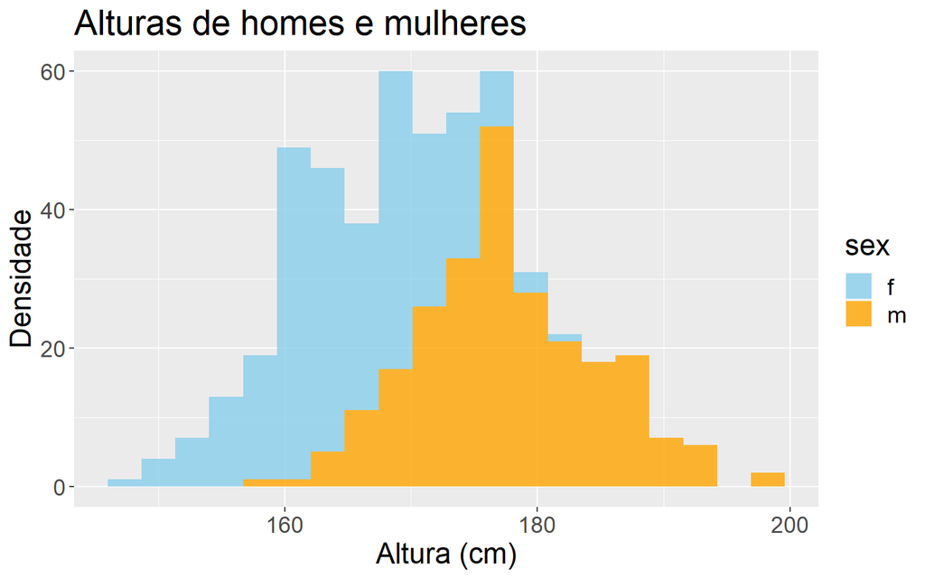

```r
bdims = mutate(
  bdims,
  sex = ifelse(sex == 1, "m", "f")
)

bdims %>%
  ggplot(aes(x = hgt, fill = sex)) +
  geom_histogram(alpha = 0.8, bins = 20) +
  labs(
    title = "Alturas de homes e mulheres",
    x = "Altura (cm)",
    y = "Densidade"
  ) +
  theme(text = element_text(size = 18)) +
  scale_fill_manual(values = c("skyblue", "orange"))
```

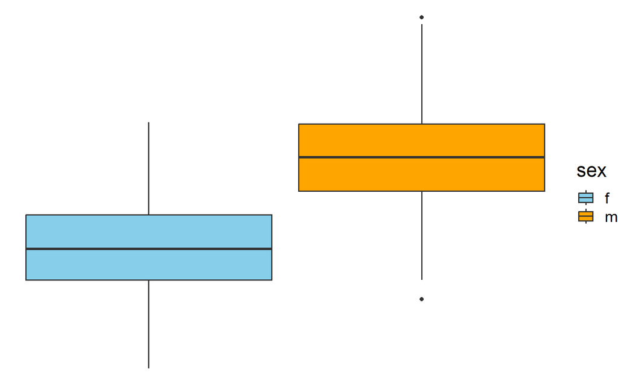

```r
bdims %>%
  ggplot(aes(y = hgt, fill = sex)) +
  geom_boxplot(size = 0.6, width = 0.1) +
  scale_fill_manual(values = c("skyblue", "orange")) +
  theme_void() +
  theme(text = element_text(size = 18))
```

Com base nos gráficos construídos e nos box plots, concluímos que os dois grupos possuem médias diferentes e distribuição aproximadamente normal.

## Distribuição normal

Em sua descrição das distribuições, você usou palavras como `forma de sino` ou `normal`? É tentador dizer isso quando nos deparamos com uma distribuição simétrica unimodal.

Para ver a precisão dessa descrição, podemos plotar uma curva de distribuição normal no topo de um histograma para ver o quanto os dados seguem uma distribuição normal.

A curva normal sobreposta deve ter a mesma média e desvio padrão dos dados. Estaremos trabalhando com as alturas das mulheres, então vamos armazená-las como um objeto separado e depois calcular algumas estatísticas que serão usadas/referenciadas posteriormente.

```r
fhgtmean = mean(fdims$hgt)
fhgtsd  = sd(fdims$hgt)
```

Em seguida, fazemos um histograma de densidade para usar como pano de fundo e usamos a `geom_function()`, da biblioteca `ggplot2`, para sobrepor uma curva de probabilidade normal ao histograma. A diferença entre um histograma de frequência e um histograma de densidade é que enquanto em um histograma de frequência as alturas das barras somam o número total de observações, em um histograma de densidade as áreas das barras somam 1. A área de cada barra pode ser calculado simplesmente como a multiplicação da altura pela largura da barra. O uso de um histograma de densidade nos permite sobrepor adequadamente uma curva de distribuição normal sobre o histograma, pois a curva é uma função de densidade de probabilidade normal. Os histogramas de frequência e densidade exibem a mesma forma exata; eles diferem apenas em seu eixo y. Você pode verificar isso comparando o histograma de frequência que você construiu anteriormente e o histograma de densidade criado pelos comandos abaixo.

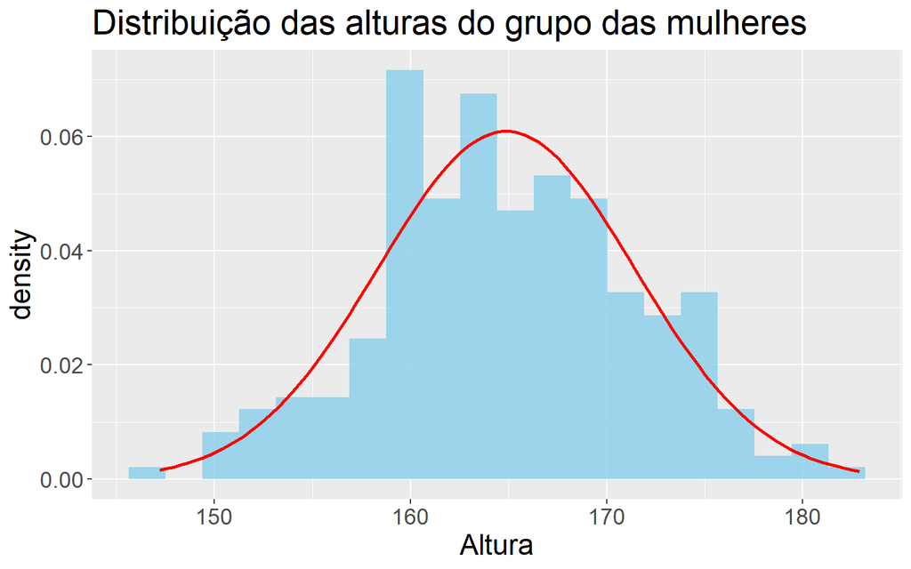

```r
fdims %>%
  ggplot(aes(x = hgt)) +
  geom_histogram(aes(y = ..density..), alpha = 0.8, fill = "skyblue", bins = 20) +
  geom_function(fun = dnorm, args = list(mean = fhgtmean, sd = fhgtsd), col = "red", linewidth = 1) +
  labs(
    title = "Distribuição das alturas do grupo das mulheres",
    x = "Altura"
  ) +
  theme(text = element_text(size = 18))
```

> Exercício 2: Com base neste gráfico, parece que os dados seguem uma distribuição quase normal?

Com base no histograma e no ajuste normal plotados, os dados seguem uma distribuição aproximadamente normal. A amostra utlizada tem 260 elementos. Provavelmente, com o aumento do tamanho da amostra, veríamos um melhor ajuste dos dados à curva de sino. De fato, já é bem conhecido que medidas biológicas em geral exibem distribuição normal.

## Avaliando a distribuição normal

Observar a forma do histograma é uma maneira de determinar se os dados parecem ter uma distribuição quase normal, mas pode ser frustrante decidir o quão próximo o histograma está da curva. Uma abordagem alternativa envolve a construção de um gráfico de probabilidade normal, também chamado de gráfico QQ normal para “quantil-quantil”.

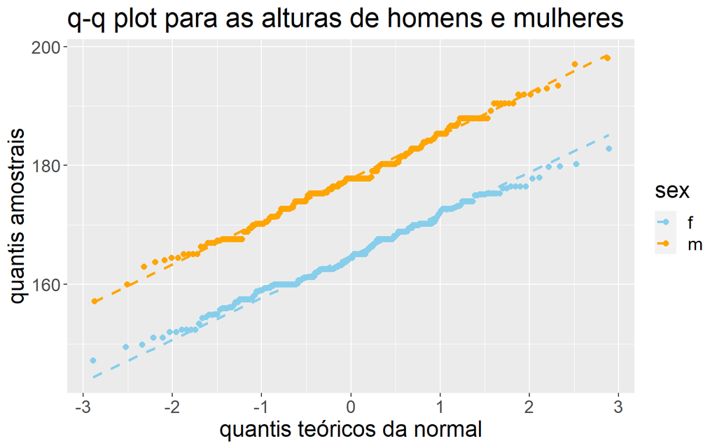

```r
bdims %>%
  ggplot(aes(sample = hgt, col = sex)) +
  geom_qq(size = 2) +
  geom_qq_line(linewidth = 1, linetype = "dashed") +
  scale_color_manual(values = c("skyblue", "orange")) +
  theme(text = element_text(size = 18)) +
  labs(
    x = "quantis teóricos da normal",
    y = "quantis amostrais",
    title = "q-q plot para as alturas de homens e mulheres"
  )
```

Um conjunto de dados quase normal resultará em um gráfico de probabilidade em que os pontos seguem a linha. Quaisquer desvios da normalidade levam a desvios desses pontos da linha. O gráfico para alturas femininas mostra pontos que tendem a seguir a linha, mas com alguns pontos errantes em direção às caudas. Ficamos com o mesmo problema que encontramos com o histograma acima: quão próximo é próximo o suficiente?

Uma maneira útil de abordar essa questão é reformulá-la como: como são os gráficos de probabilidade para dados que sei que vieram de uma distribuição normal? Podemos responder a isso simulando dados de uma distribuição normal usando `rnorm`.

```r
set.seed(42)
sim_norm = rnorm(
  n = nrow(fdims),
  mean = fhgtmean,
  sd = fhgtsd
)
```

O primeiro argumento indica quantos números você gostaria de gerar, que especificamos como sendo o mesmo número de alturas no conjunto de dados `fdims` usando a função `nrow()`. Os dois últimos argumentos determinam a média e o desvio padrão da distribuição normal a partir da qual a amostra simulada será gerada. Podemos dar uma olhada na forma de nosso conjunto de dados simulado, `sim_norm`, bem como em seu gráfico de probabilidade normal.

> Exercício 3: Faça um gráfico de probabilidade normal de `sim_norm`. Todos os pontos caem na linha? Como esse gráfico se compara ao gráfico de probabilidade para os dados reais?

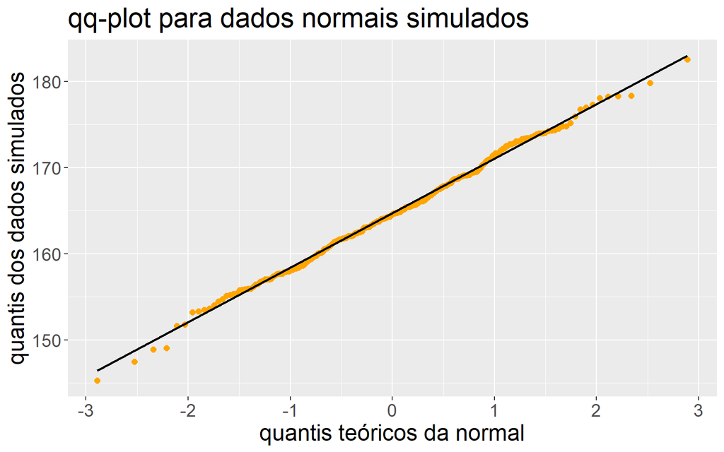

```r
sim_norm = as.data.frame(sim_norm)
sim_norm %>%
  ggplot(aes(sample = sim_norm)) +
  geom_qq(col = "orange", size = 2) +
  geom_qq_line(linewidth = 1) +
  labs(
    x = "quantis teóricos da normal",
    y = "quantis dos dados simulados",
    title = "qq-plot para dados normais simulados"
  ) +
  theme(text = element_text(size = 18))
```

Conforme observamos no gráfico acima, a maioria dos pontos caíram sobre a reta. Contudo, alguns pontos se distanciaram ligeiramente da reta, especialmente nas caldas da distribuição.

Ainda melhor do que comparar o gráfico original com um único gráfico gerado a partir de uma distribuição normal é compará-lo com muitos outros gráficos usando a seguinte função. Pode ser útil clicar no botão de zoom na janela do gráfico.

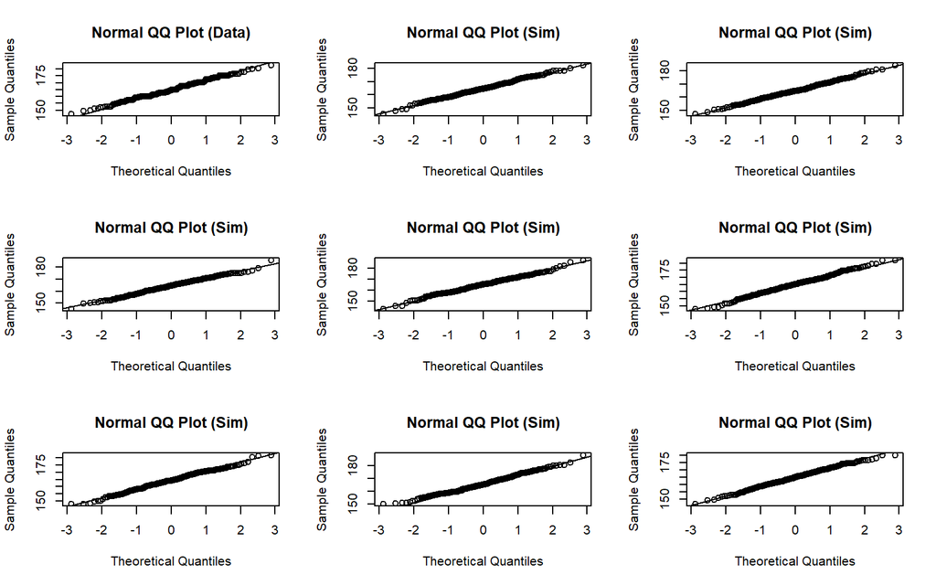

```r
set.seed(42)
qqnormsim(fdims$hgt)
```

> Exercício 4: O gráfico de probabilidade normal para `fdims$hgt` parece semelhante aos gráficos criados para os dados simulados? Ou seja, os gráficos fornecem evidências de que as alturas femininas são quase normais?

Sim, vemos que o qq-plot para os dados reais é muito semelhante àqueles construídos para os dados simulados, o que indica que os dados das alturas são aproximadamente normais.

> Exercício 5: Usando a mesma técnica, determine se os pesos femininos parecem ou não vir de uma distribuição normal.

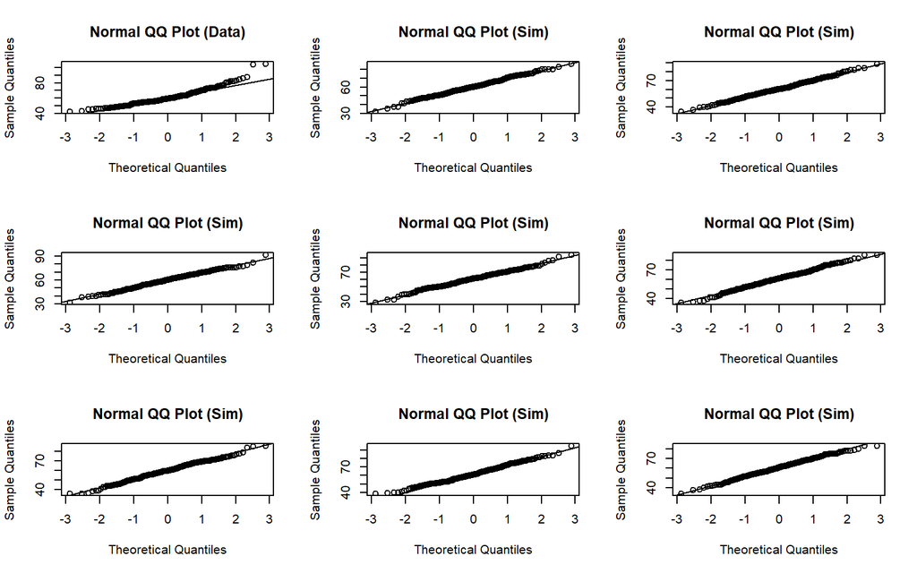

```r
set.seed(42)
qqnormsim(fdims$wgt)
```

No caso dos dados de peso feminino, vemos que o gráfico qq-plot para os dados reais se afastam consideravelmente da normalidade nas caldas.

## Probabilidades Normais

Ok, agora você tem uma série de ferramentas para julgar se uma variável é ou não normalmente distribuída. Por que devemos nos importar?

Acontece que os estatísticos sabem muito sobre a distribuição normal. Depois de decidirmos que uma variável aleatória é aproximadamente normal, podemos responder a todos os tipos de perguntas sobre essa variável relacionadas à probabilidade. Tomemos, por exemplo, a pergunta: “Qual é a probabilidade de uma jovem adulta escolhida aleatoriamente ter mais de 6 pés (cerca de 182 cm)?” (**O estudo que publicou este conjunto de dados é claro ao apontar que a amostra não foi aleatória e, portanto, a inferência para uma população geral não é sugerida. Fazemos isso aqui apenas como um exercício.**)

Se assumirmos que as alturas femininas são normalmente distribuídas (uma aproximação muito próxima também é aceitável), podemos encontrar essa probabilidade calculando um quantil $z$ e consultando uma tabela $z$ (também chamada de tabela de probabilidade normal). No R, isso é feito em uma etapa com a função `pnorm`.

```r
1 - pnorm(q = 182, mean = fhgtmean, sd = fhgtsd)
```

```
## [1] 0.004434387
```

No trecho acima, subtraímos a probabilidade retornada da unidade porque queremos o resultado da cauda direita, ou seja, a probabilidade de que a uma mulher selecionada ao acaso tenha mais que 182 cm, dados que, supostamente, a população de mulheres tem peso que se distribui normalmente com a média e desvio padrão obtida do conjunto de dados da amostra apresentada neste relatório. Outra maneira de fazer isso é a seguinte:

```r
pnorm(q = 182, mean = fhgtmean, sd = fhgtsd, lower.tail = F)
```

```
## [1] 0.004434387
```

O resultado é o mesmo obtido anteriormente. A função `pnorm()` calcula a probabilidade acumulada à esquerda do quantil fornecido. Fornecemos então o argumento `lower.tail = FALSE` para inverter a calda, já que queremos a probabilidade do peso ser maior que 182 cm.

Assumir uma distribuição normal nos permitiu calcular uma probabilidade teórica. Se quisermos calcular a probabilidade empiricamente, simplesmente precisamos determinar quantas observações ficam acima de 182 e dividir esse número pelo tamanho total da amostra:

```r
sum(fdims$hgt > 182) / nrow(fdims)
```

```
## [1] 0.003846154
```

Embora as probabilidades não sejam exatamente as mesmas, elas são razoavelmente próximas. Quanto mais próxima a sua distribuição estiver da normal, mais precisas serão as probabilidades teóricas.

> Exercício 6: Escreva duas questões de probabilidade que você gostaria de responder; um em relação às alturas femininas e outro em relação aos pesos femininos. Calcule essas probabilidades usando tanto a distribuição normal teórica quanto a distribuição empírica (quatro probabilidades ao todo). Qual variável, altura ou peso, apresentou maior concordância entre os dois métodos?

Assumindo a distribuição normal dos pesos e das alturas femininas na população geral, vamos calcular as probabilidades do peso de uma mulher selecionada ao acaso ser menor que 50 e da altura ser menor que 160 e comarar com os respectivos valores empíricos:

```r
fwgtmean = mean(fdims$wgt)
fwgtsd = sd(fdims$wgt)

data.frame(
  teorico =
    c(pnorm(q = 160, mean = fhgtmean, sd = fhgtsd), pnorm(q = 50, mean = fwgtmean, sd = fwgtsd)),
  empirico =
    c(sum(fdims$hgt < 160) / nrow(fdims), sum(fdims$wgt < 50) / nrow(fdims)),
  row.names = c("Altura", "Peso")
) %>%
  mutate(
    diferenca = teorico - empirico
  ) %>%
  kable() %>%
  kable_styling(
    full_width = F,
    bootstrap_options = c("striped", "hover", "condensed",
                          "responsive")
    )
```

|  | teorico | empirico | diferenca |
| --- | --- | --- | --- |
| Altura | 0.2282939 | 0.1923077 | 0.0359862 |
| Peso | 0.1351430 | 0.1038462 | 0.0312969 |

Como podemos ver, a diferença nominal é maior para a diferença entre as distribuições das alturas teórica e empírica.